# DAT205x: Introduction to Data Analysis using R. Lab8

## Scenario

Lastly, Lucy wants to have more information about the customer demographics in addition to the already available age and gender. Since your data has Customer ID for each row, you can “connect” these rows with your customer demographics database. Your customer demographics is stored in file “Customer_demographics.txt”.

Load necessary libraries

```r
library(tidyverse)
library(RColorBrewer)
```

Load data for Lab8

```r
my_data <- readRDS("./week2/data4week3.rds")
add_data <- read.table("./week8/Customer_demographics.txt", sep = ",", header = T) %>%
    as_data_frame()
```

Let’s bring the customer database into your R Markdown file: add the **MaritalStatus** and **TotalChildren** to my_data

```r
new_add <- add_data %>%
    select(Customer.ID, MaritalStatus, TotalChildren)

new_my <- my_data %>%
    select(`Customer ID`, `Order Quantity`, `Product Category`) %>%
    left_join(new_add, c("Customer ID" = "Customer.ID"))
```

#### **Question 1:** For those customers who bought bikes, what are the top three (bought the most quantity) customer profiles (marital status and number of children)?

```r
ans_1 <- my_data %>%
    select(`Customer ID`, `Order Quantity`, `Product Category`) %>%
    left_join(add_data %>%
                  select(Customer.ID, MaritalStatus, TotalChildren), c("Customer ID" = "Customer.ID")) %>%
    filter(`Product Category` == "Bikes") %>%
    group_by(MaritalStatus, TotalChildren) %>%
    summarise(`Total Order` = sum(`Order Quantity`)) %>%
    arrange(desc(`Total Order`)) %>%
    ungroup()
```

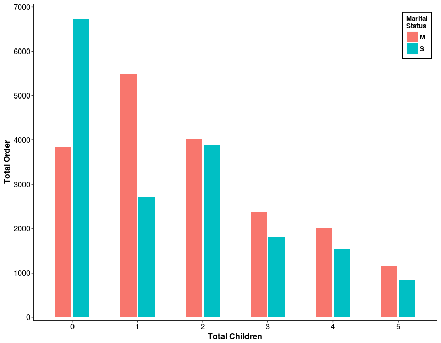

#### **Answer:**

1. Single without child
2. Married with one child
3. Married with two children

Now, replace the MaritalStatus and TotalChildren fields with the YearlyIncome field from the Customer_demographic table.

#### **Question 2:** For those customers who bought bikes, what are the top three (bought the most quantity) income brackets? (Rank from highest to Lowest)

```r
ans_2 <- my_data %>%
    select(`Customer ID`, `Order Quantity`, `Product Category`) %>%
    left_join(add_data %>%
                  select(Customer.ID, YearlyIncome), c("Customer ID" = "Customer.ID")) %>%
    filter(`Product Category` == "Bikes") %>%
    group_by(YearlyIncome)%>%
    summarise(`Total Quantity` = sum(`Order Quantity`)) %>%
    arrange(desc(`Total Quantity`)) %>%
    ungroup()
```

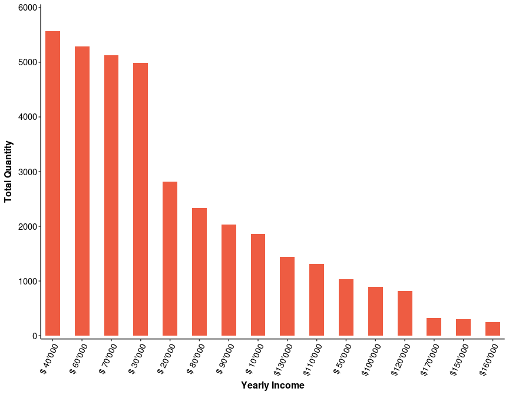

#### **Answer:**

1. $40`000
2. $60`000
3. $70`000

Now, remove the **YearlyIncome** field and replace it with the **EnglishEducation** field from the add_data tibble.

#### **Question 3:** For those customers who bought bikes, what are the top two (bought the most quantity) education levels?

```r
ans_3 <- my_data %>%
    select(`Customer ID`, `Order Quantity`, `Product Category`) %>%
    left_join(add_data %>%
                  select(Customer.ID, EnglishEducation), c("Customer ID" = "Customer.ID")) %>%
    filter(`Product Category` == "Bikes") %>%
    group_by(EnglishEducation)%>%
    summarise(`Total Quantity` = sum(`Order Quantity`)) %>%
    arrange(desc(`Total Quantity`)) %>%
    ungroup()
```

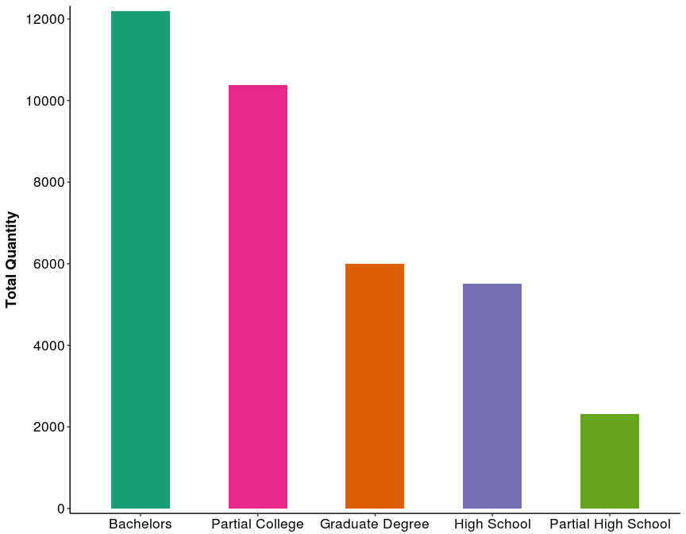

#### **Answer:**

1. Bachelors
2. Partial College

Lastly, remove the EnglishEducation field from the Rows and replace it with the HouseOwnerFlag field from the Customer_demographics table. Format the Sum of Order Quantity to show as Percentage of Grand Total with two decimal places.

#### **Question 4:** What is the percentage of the customers who bought Bikes and are house owners?

```r
ans_4 <- my_data %>%
    select(`Customer ID`, `Order Quantity`, `Product Category`) %>%
    left_join(add_data %>%
                  select(Customer.ID, HouseOwnerFlag), c("Customer ID" = "Customer.ID")) %>%
    filter(`Product Category` == "Bikes") %>%
    group_by(HouseOwnerFlag) %>%
    summarise(Total = sum(`Order Quantity`)) %>%
    mutate(`Grand Total, %` = formatC(Total / sum(Total) * 100, digits = 2, format = "f") %>%
               as.numeric()) %>%
    arrange(desc(`Grand Total, %`)) %>%
    ungroup()
```

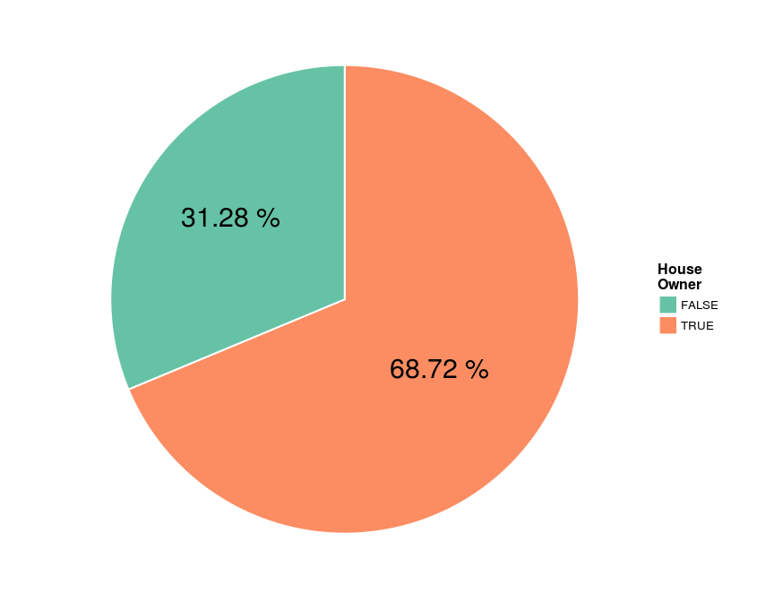

#### **Answer:** 68.72